# 1주차 - 딥러닝을 이용한 자연어처리 입문(위키독스)

```python
from google.colab import drive
drive.mount('/content/drive')
```

[output not shown]

# Library

## 1. Tensorflow

구글이 2015년에 공개한 머신 러닝 오픈소스 라이브러리.

머신 러닝과 딥 러닝을 직관적이고 손쉽게 할 수 있도록 설계되었음.

## 2. Keras

딥 러닝 프레임워크인 텐서플로우에 대한 추상화 된 API를 제공.

텐서플로우보다 간단한 코드 작성 가능.

## 3. Gensim

토픽 모델링과 자연어 처리 등을 수행할 수 있게 해주는 오픈 소스 라이브러리.

Word2Vec과 토픽모델링 사용 가능.

## 4. Scikit-learn

나이브 베이즈 분류, 서포트 벡터 머신 등 다양한 머신 러닝 모듈 제공.

아이리스 데이터, 당뇨병 데이터 등 자체 데이터 제공.

```python
import nltk
nltk.download('treebank')
```

```
True
```

```python
!pip install konlpy
```

[output not shown]

```python
import konlpy
konlpy.__version__
```

```
'0.5.2'
```

## Pandas

#### 1. Series

- 시리즈 클래스는 1차원 배열의 값(values)에 각 값에 대응되는 인덱스(index)를 부여할 수 있는 구조

#### 2. Data Frame

- 데이터프레임은 2차원 리스트를 매개변수로 전달.
- 2차원이므로 행방향 인덱스(index)와 열방향 인덱스(column)가 존재. 즉, 행과 열을 가지는 자료구조임.
- 시리즈가 인덱스(index)와 값(values)으로 구성된다면, 데이터프레임은 열(columns)까지 추가되어 열(columns), 인덱스(index), 값(values)으로 구성됨.
- df.head(n) - 앞 부분을 n개만 보기
- df.tail(n) - 뒷 부분을 n개만 보기
- df['열이름'] - 해당되는 열을 확인

```python
import pandas as pd
```

```python
sr = pd.Series([17000, 18000, 1000, 5000],
       index=["피자", "치킨", "콜라", "맥주"])
print(sr)
print(sr.values)
print(sr.index)
```

```
피자    17000
치킨    18000
콜라     1000
맥주     5000
dtype: int64
[17000 18000  1000  5000]
Index(['피자', '치킨', '콜라', '맥주'], dtype='object')
```

```python
values = [[1, 2, 3], [4, 5, 6], [7, 8, 9]]
index = ['one', 'two', 'three']
columns = ['A', 'B', 'C']

df = pd.DataFrame(values, index=index, columns=columns)
print(df)
```

```
       A  B  C
one    1  2  3
two    4  5  6
three  7  8  9
```

```python
print(df.index)
print(df.columns)
print(df.values)
```

```
Index(['one', 'two', 'three'], dtype='object')
Index(['A', 'B', 'C'], dtype='object')
[[1 2 3]
 [4 5 6]
 [7 8 9]]
```

```python
data = [
    ['1000', 'Steve', 90.72],
    ['1001', 'James', 78.09],
    ['1002', 'Doyeon', 98.43],
    ['1003', 'Jane', 64.19],
    ['1004', 'Pilwoong', 81.30],
    ['1005', 'Tony', 99.14],
]
df = pd.DataFrame(data)
print(df)
```

```
      0         1      2
0  1000     Steve  90.72
1  1001     James  78.09
2  1002    Doyeon  98.43
3  1003      Jane  64.19
4  1004  Pilwoong  81.30
5  1005      Tony  99.14
```

```python
df = pd.DataFrame(data, columns=['학번', '이름', '점수'])
print(df)
```

```
     학번        이름     점수
0  1000     Steve  90.72
1  1001     James  78.09
2  1002    Doyeon  98.43
3  1003      Jane  64.19
4  1004  Pilwoong  81.30
5  1005      Tony  99.14
```

```python
data = { '학번' : ['1000', '1001', '1002', '1003', '1004', '1005'],
'이름' : [ 'Steve', 'James', 'Doyeon', 'Jane', 'Pilwoong', 'Tony'],
         '점수': [90.72, 78.09, 98.43, 64.19, 81.30, 99.14]}

df = pd.DataFrame(data)
print(df)
```

```
     학번        이름     점수
0  1000     Steve  90.72
1  1001     James  78.09
2  1002    Doyeon  98.43
3  1003      Jane  64.19
4  1004  Pilwoong  81.30
5  1005      Tony  99.14
```

```python
print(df.head(3))
print(df.tail(3))
print(df['학번'])
```

```
     학번      이름     점수
0  1000   Steve  90.72
1  1001   James  78.09
2  1002  Doyeon  98.43
     학번        이름     점수
3  1003      Jane  64.19
4  1004  Pilwoong  81.30
5  1005      Tony  99.14
0    1000
1    1001
2    1002
3    1003
4    1004
5    1005
Name: 학번, dtype: object
```

```python
print(df.index)
```

```
RangeIndex(start=0, stop=6, step=1)
```

## NUMPY

1. np.array() # 리스트, 튜플, 배열로 부터 ndarray를 생성
2. np.asarray() # 기존의 array로 부터 ndarray를 생성
3. np.arange() # range와 비슷
4. np.linspace(start, end, num) # [start, end] 균일한 간격으로 num개 생성
5. np.logspace(start, end, num) # [start, end] log scale 간격으로 num개 생성

```python
import numpy as np
```

```python
a = np.array([1, 2, 3, 4, 5]) #리스트를 가지고 1차원 배열 생성
print(type(a))
print(a)
```

```
<class 'numpy.ndarray'>
[1 2 3 4 5]
```

```python
b = np.array([[10, 20, 30], [ 60, 70, 80]])
print(b)
```

```
[[10 20 30]
 [60 70 80]]
```

```python
print(a.ndim) #차원 출력
print(a.shape) #크기 출력
print(b.ndim) #차원 출력
print(b.shape) #크기 출력
```

```
1
(5,)
2
(2, 3)
```

```python
a = np.zeros((2,3)) # 모든값이 0인 2x3 배열 생성.
print(a)
```

```
[[0. 0. 0.]
 [0. 0. 0.]]
```

```python
a = np.ones((2,3)) # 모든값이 1인 2x3 배열 생성.
print(a)
```

```
[[1. 1. 1.]
 [1. 1. 1.]]
```

```python
a = np.full((2,2), 7) # 모든 값이 특정 상수인 배열 생성. 이 경우에는 7.
print(a)
```

```
[[7 7]
 [7 7]]
```

```python
a = np.eye(3) # 대각선으로는 1이고 나머지는 0인 2차원 배열을 생성.
print(a)
```

```
[[1. 0. 0.]
 [0. 1. 0.]
 [0. 0. 1.]]
```

```python
a = np.random.random((2,2)) # 임의의 값으로 채워진 배열 생성
print(a)
```

```
[[0.2902947  0.2354292 ]
 [0.77328122 0.21608107]]
```

```python
a = np.arange(10) #0부터 9까지
print(a)
```

```
[0 1 2 3 4 5 6 7 8 9]
```

```python
a = np.arange(1, 10, 2) #1부터 9까지 +2씩 적용되는 범위
print(a)
```

```
[1 3 5 7 9]
```

```python
a = np.array(np.arange(30)).reshape((5,6))
print(a)
```

```
[[ 0  1  2  3  4  5]
 [ 6  7  8  9 10 11]
 [12 13 14 15 16 17]
 [18 19 20 21 22 23]
 [24 25 26 27 28 29]]
```

```python
a = np.array([[1, 2, 3], [4, 5, 6]])
print(a)
```

```
[[1 2 3]
 [4 5 6]]
```

```python
b=a[0:2, 0:2]
print(b)
```

```
[[1 2]
 [4 5]]
```

```python
b=a[0, :] # 첫번째 행 출력
print(b)
```

```
[1 2 3]
```

```python
b=a[:, 1] # 두번째 열 출력
print(b)
```

```
[2 5]
```

```python
a = np.array([[1,2], [4,5], [7,8]])
print(a)
b = a[[2, 1],[1, 0]] # a[[ row2, row1],[col1, col0]]을 의미함.
print(b)
```

```
[[1 2]
 [4 5]
 [7 8]]
[8 4]
```

```python
x = np.array([1,2,3])
y = np.array([4,5,6])
```

```python
# b = x + y # 각 요소에 대해서 더함
b = np.add(x, y)
print(b)
```

```
[5 7 9]
```

```python
# b = x - y # 각 요소에 대해서 빼기
b = np.subtract(x, y)
print(b)
```

```
[-3 -3 -3]
```

```python
# b = b * x # 각 요소에 대해서 곱셈
b = np.multiply(b, x) # 와 동일함
print(b)
```

```
[-3 -6 -9]
```

```python
# b = b / x # 각 요소에 대해서 나눗셈
b = np.divide(b, x) # 와 동일함
print(b)
```

```
[-3. -3. -3.]
```

```python
a = np.array([[1,2],[3,4]])
b = np.array([[5,6],[7,8]])

c = np.dot(a, b) # 행렬곱
d = a * b # 각 위치의 곱
print(c)
print(d)
```

```
[[19 22]
 [43 50]]
[[ 5 12]
 [21 32]]
```

## Matplotlib

- 데이터를 차트(chart)나 플롯(plot)으로 시각화(visulaization)하는 패키지

```python
import matplotlib
```

```python
%matplotlib inline # 주피터 노트북에 그림을 표시하도록 지정
import matplotlib.pyplot as plt
```

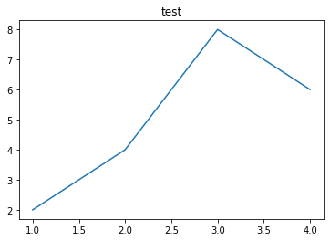

```python
plt.title('test')
plt.plot([1,2,3,4],[2,4,8,6])
plt.show()
```

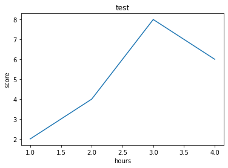

```python
plt.title('test')
plt.plot([1,2,3,4],[2,4,8,6])
plt.xlabel('hours')
plt.ylabel('score')
plt.show()
```

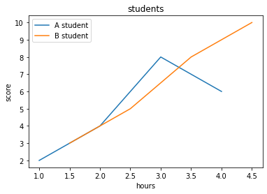

```python
plt.title('students')
plt.plot([1,2,3,4],[2,4,8,6]) # (1, 2), (2, 4), (3, 8), (4, 6)
plt.plot([1.5,2.5,3.5,4.5],[3,5,8,10]) #라인 새로 추가 (1.5, 3), (2.5, 5), (3.5, 8), (4.5, 10)
plt.xlabel('hours')
plt.ylabel('score')
plt.legend(['A student', 'B student']) #범례 삽입
plt.show()
```

## Pandas Profiling

```python
import pandas as pd
import pandas_profiling
data = pd.read_csv('/spam.csv',encoding='latin1')
data[:5]
```

|  | v1 | v2 | Unnamed: 2 | Unnamed: 3 | Unnamed: 4 |
| --- | --- | --- | --- | --- | --- |
| 0 | ham | Go until jurong point, crazy.. Available only ... | NaN | NaN | NaN |
| 1 | ham | Ok lar... Joking wif u oni... | NaN | NaN | NaN |
| 2 | spam | Free entry in 2 a wkly comp to win FA Cup fina... | NaN | NaN | NaN |
| 3 | ham | U dun say so early hor... U c already then say... | NaN | NaN | NaN |
| 4 | ham | Nah I don't think he goes to usf, he lives aro... | NaN | NaN | NaN |

```python
pr=data.profile_report()
pr
```

[interactive chart not shown]

# 텍스트 전처리 (Text preprocessing)

## Tokenization

- 전처리의 종류: 토큰화(tokenization), 정제(cleaning), 정규화(normalization)
- 토큰화란? 주어진 코퍼스(corpus)에서 토큰(token)이라 불리는 단위로 나누는 작업. 토큰의 단위가 상황에 따라 다르지만, 보통 의미있는 단위(한국어에서의 최소단위: 형태소)로 토큰을 정의합니다.

### Word Tokenization

- 토큰의 기준을 단어(word)로 하는 경우.
- ex) 구두점(punctuation)을 기준으로 토큰화
- - 입력: Time is an illusion. Lunchtime double so!
- - 출력 : "Time", "is", "an", "illustion", "Lunchtime", "double", "so"
- 보통 토큰화 작업은 단순히 구두점이나 특수문자를 전부 제거하는 정제(cleaning) 작업을 수행하는 것만으로 해결되지 않음. 구두점이나 특수문자를 전부 제거하면 토큰이 의미를 잃어버리는 경우가 발생하기도 한다. 심지어 띄어쓰기 단위로 자르면 사실상 단어 토큰이 구분되는 영어와 달리, 한국어는 띄어쓰기만으로는 단어 토큰을 구분하기 어려움.

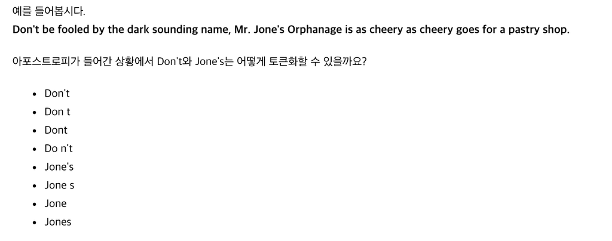

```python
!pip install nltk
```

```python
nltk.download('punkt')
from nltk.tokenize import word_tokenize
print(word_tokenize("Don't be fooled by the dark sounding name, Mr. Jone's Orphanage is as cheery as cheery goes for a pastry shop."))
```

```
['Do', "n't", 'be', 'fooled', 'by', 'the', 'dark', 'sounding', 'name', ',', 'Mr.', 'Jone', "'s", 'Orphanage', 'is', 'as', 'cheery', 'as', 'cheery', 'goes', 'for', 'a', 'pastry', 'shop', '.']
```

```python
from nltk.tokenize import WordPunctTokenizer
print(WordPunctTokenizer().tokenize("Don't be fooled by the dark sounding name, Mr. Jone's Orphanage is as cheery as cheery goes for a pastry shop."))
```

```
['Don', "'", 't', 'be', 'fooled', 'by', 'the', 'dark', 'sounding', 'name', ',', 'Mr', '.', 'Jone', "'", 's', 'Orphanage', 'is', 'as', 'cheery', 'as', 'cheery', 'goes', 'for', 'a', 'pastry', 'shop', '.']
```

```python
from tensorflow.keras.preprocessing.text import text_to_word_sequence
print(text_to_word_sequence("Don't be fooled by the dark sounding name, Mr. Jone's Orphanage is as cheery as cheery goes for a pastry shop."))
```

```
["don't", 'be', 'fooled', 'by', 'the', 'dark', 'sounding', 'name', 'mr', "jone's", 'orphanage', 'is', 'as', 'cheery', 'as', 'cheery', 'goes', 'for', 'a', 'pastry', 'shop']
```

### 토큰화에서 고려해야할 사항

토큰화 작업을 단순하게 코퍼스에서 구두점을 제외하고 공백 기준으로 잘라내는 작업이라고 간주할 수는 없다.

#### 1. 구두점이나 특수 문자를 단순 제외해서는 안 된다.

- 구두점조차도 하나의 토큰으로 분류될 수 있기 때문.
- 온점(.)과 같은 경우는 문장의 경계를 알 수 있는데 도움이 되므로 단어를 뽑아낼 때, 온점(.)을 제외하지 않을 수 있다.
- 단어 자체에서 구두점을 갖고 있는 경우도 있음. m.p.h, Ph.D, AT&T.
- 달러($)나 슬래시(/)로 예를 들어보면, $45.55와 같은 가격을 의미 하기도 하고, 01/02/06은 날짜를 의미하기도 함. 보통 이런 경우 45와 55로 따로 분류해서는 안됨.
- 숫자 사이에 컴마(,)가 들어가는 경우도 있습니다. 보통 수치나 가격을 표현할 때는 123,456,789, 100,000₩ 와 같이 세 자리 단위로 컴마가 들어갑니다.

#### 2. 줄임말과 단어 내에 띄어쓰기가 있는 경우.

- 토큰화 작업에서 종종 영어권 언어의 어퍼스트로피(')는 압축된 단어를 다시 펼치는 역할을 하기도 한다. 예를 들어 what're는 what are의 줄임말이며, we're는 we are의 줄임말임. 이 예에서 re를 접어(clitic)라고 하는데, 즉 단어가 줄임말로 쓰일 때 생기는 형태이다. I am을 줄인 I'm에서, m이 접어임.
- New York이라는 단어나 rock 'n' roll은 하나의 단어이지만 중간에 띄어쓰기가 존재한다. 사용 용도에 따라서, 하나의 단어 사이에 띄어쓰기가 있는 경우에도 하나의 토큰으로 봐야하는 경우도 있을 수 있으므로, 토큰화 작업은 저러한 단어를 하나로 인식할 수 있는 능력이 필요.

#### 3. 표준 토큰화 예제

##### Penn Treebank Tokenization

- 규칙 1. 하이푼으로 구성된 단어는 하나로 유지한다.
- 규칙 2. doesn't와 같이 아포스트로피로 '접어'가 함께하는 단어는 분리해준다.

```python
from nltk.tokenize import TreebankWordTokenizer
tokenizer=TreebankWordTokenizer()
text="Starting a home-based restaurant may be an ideal. it doesn't have a food chain or restaurant of their own."
print(tokenizer.tokenize(text))
```

```
['Starting', 'a', 'home-based', 'restaurant', 'may', 'be', 'an', 'ideal.', 'it', 'does', "n't", 'have', 'a', 'food', 'chain', 'or', 'restaurant', 'of', 'their', 'own', '.']
```

### 문장 토큰화 (Sentence Tokenization)

- 토큰의 단위가 문장(sentence)의 경우 문장토큰화 (sentence tokenization) 또는 문장 분류(sentence segmentation)라고 한다.
- 코퍼스가 정제되지 않은 상태일 때, 코퍼스는 문장 단위로 구분되어있지 않을 가능성이 높다. 이를 사용하고자 하는 용도에 맞게 하기 위해서는 문장 토큰화가 필요할 수 있음.
- !나 ?는 문장의 구분을 위한 꽤 명확한 구분자(boundary) 역할을 하지만 온점은 문장의 끝이 아니더라도 등장할 수 있기 때문에 문장단위의 기준은 항상 달라질 수 있다.

```python
from nltk.tokenize import sent_tokenize
text="His barber kept his word. But keeping such a huge secret to himself was driving him crazy. Finally, the barber went up a mountain and almost to the edge of a cliff. He dug a hole in the midst of some reeds. He looked about, to mae sure no one was near."
print(sent_tokenize(text))
```

```
['His barber kept his word.', 'But keeping such a huge secret to himself was driving him crazy.', 'Finally, the barber went up a mountain and almost to the edge of a cliff.', 'He dug a hole in the midst of some reeds.', 'He looked about, to mae sure no one was near.']
```

```python
from nltk.tokenize import sent_tokenize
text="I am actively looking for Ph.D. students. and you are a Ph.D student."
print(sent_tokenize(text))
```

```
['I am actively looking for Ph.D. students.', 'and you are a Ph.D student.']
```

```python
!pip install kss # korean sentence splitter
```

```python
import kss
text='딥 러닝 자연어 처리가 재미있기는 합니다. 그런데 문제는 영어보다 한국어로 할 때 너무 어려워요. 농담아니에요. 이제 해보면 알걸요?'
print(kss.split_sentences(text))
```

```
['딥 러닝 자연어 처리가 재미있기는 합니다.', '그런데 문제는 영어보다 한국어로 할 때 너무 어려워요.', '농담아니에요.', '이제 해보면 알걸요?']
```

### 5. 이진 분류기(Binary Classifier)

1. 온점(.)이 단어의 일부분일 경우. 즉, 온점이 약어(abbreivation)로 쓰이는 경우
2. 온점(.)이 정말로 문장의 구분자(boundary)일 경우
- 두 개의 클래스를 머신러닝을 통해 분류한다. 이 경우 약어사전(abbreivation)이 유용하게 사용됨.
- 문장 토큰화를 수행하는 오픈 소스로는 NLTK, OpenNLP, 스탠포드 CoreNLP, splitta, LingPipe 등이 있다.
- 문장 토큰화 규칙을 짤 때, 발생할 수 있는 여러가지 예외사항을 다룬 참고 링크
- https://tech.grammarly.com/blog/posts/How-to-Split-Sentences.html

### 6. 한국어에서의 토큰화의 어려움.

- 영어는 New York과 같은 합성어나 he's 와 같이 줄임말에 대한 예외처리만 한다면, 띄어쓰기(whitespace)를 기준으로 하는 띄어쓰기 토큰화를 수행해도 단어 토큰화가 잘 작동한다.
- 반면 한국어는 교착어이기 때문에, 띄어쓰기 단어가 되는 '어절' 토큰화는 한국어 NLP에서 지양된다.
- 1. 한국어에는 '조사'가 존재한다.
     - '그가', '그에게', '그를', '그와', '그는'과 같이 다양한 조사가 띄어쓰기 없이 바로 붙게되는데, 이 경우 정제 시 같은 단어임에도 다른 단어로 인식됨. 따라서 조사까지 분리해 줄 필요가 있다.
     - 한국어 토큰화에서는 형태소(morpheme)란 개념을 반드시 이해해야 한다. 형태소(morpheme)란 "뜻을 가진 가장 작은 말의 단위"이며 형태소는 자립 형태소와 의존 형태소로 분류할 수 있다.
     - 자립 형태소 : 접사, 어미, 조사와 상관없이 자립하여 사용할 수 있는 형태소. 그 자체로 단어가 된다. 체언(명사, 대명사, 수사), 수식언(관형사, 부사), 감탄사 등이 있다.
     - 의존 형태소 : 다른 형태소와 결합하여 사용되는 형태소. 접사, 어미, 조사, 어간를 말한다.
     - ex) 문장 : 에디가 딥러닝책을 읽었다
     - 이를 형태소 단위로 분해하면 다음과 같습니다.
     - 자립 형태소 : 에디, 딥러닝책
     - 의존 형태소 : -가, -을, 읽-, -었, -다
- 이를 통해 유추할 수 있는 것은 한국어에서 영어에서의 단어 토큰화와 유사한 형태를 얻으려면 어절 토큰화가 아니라 형태소 토큰화를 수행해야한다는 겁니다.
- 1. 한국어는 띄어쓰기가 영어보다 잘 지켜지지 않는다.
     - 한국어는 영어권 언어와 비교하여 띄어쓰기가 어렵고, 또 잘 지켜지지 않는 경향이 있는데 한국어의 경우 띄어쓰기가 지켜지지 않아도 글을 쉽게 이해할 수 있기 때문이다.
     - ex1) 제가이렇게띄어쓰기를전혀하지않고글을썼다고하더라도글을이해할수있습니다.
     - ex2) Tobeornottobethatisthequestion
     - 영어의 경우 띄어쓰기를 하지 않으면 손쉽게 알아보기 어려운 문장들이 생긴다. 이는 한국어(모아쓰기 방식)와 영어(풀어쓰기 방식)라는 언어적 특성차이에 기인함.

### 7. 품사 태깅(Part-of-speech tagging)

- 단어는 표기는 같지만, 품사에 따라서 단어의 의미가 달라지기도 한다. 예를 들어 'fly'는 동사로는 '날다'이지만 명사로는 '파리'라는 의미인 것처럼 한국어에서도 '못'이라는 단어는 명사로서는 "망치를 사용해서 목재 따위를 고정하는 물건"을 의미하는 반면 부사로서의 '못'은 '먹는다', '달린다'와 같은 동작 동사를 할 수 없다는 의미이다.
- 즉, 단어의 의미를 제대로 파악하기 위해서는 해당 단어가 어떤 품사인지 알아볼 필요가 있다. 이렇게 해당 단어의 품사를 알아보는 작업을 품사 태깅(part-of-speech tagging)이라고 한다.

### 8. NLTK와 KoNLPy를 이용한 영어, 한국어 토큰화 실습

- NLTK에서는 영어 코퍼스에 품사 태깅 기능을 지원한다. 품사를 어떻게 명명하고, 태깅하는지의 기준은 여러가지가 있는데, NLTK에서는 Penn Treebank POS Tags라는 기준을 사용.
- PRP: 인칭 대명사
- VBP: 동사
- RB: 부사
- VBG: 현재부사
- IN은 전치사
- NNP: 고유 명사
- NNS: 복수형 명사
- CC: 접속사
- DT: 관사

KoNLPy의 종류

- Okt(Open Korea Text)
- 메캅(Mecab)
- 코모란(Komoran)
- 한나눔(Hannanum)
- 꼬꼬마(Kkma)

```python
from nltk.tokenize import word_tokenize
text="I am actively looking for Ph.D. students. and you are a Ph.D. student."
print(word_tokenize(text))
```

```
['I', 'am', 'actively', 'looking', 'for', 'Ph.D.', 'students', '.', 'and', 'you', 'are', 'a', 'Ph.D.', 'student', '.']
```

```python
nltk.download('averaged_perceptron_tagger')
from nltk.tag import pos_tag
x=word_tokenize(text)
pos_tag(x)
```

```
[('I', 'PRP'),
 ('am', 'VBP'),
 ('actively', 'RB'),
 ('looking', 'VBG'),
 ('for', 'IN'),
 ('Ph.D.', 'NNP'),
 ('students', 'NNS'),
 ('.', '.'),
 ('and', 'CC'),
 ('you', 'PRP'),
 ('are', 'VBP'),
 ('a', 'DT'),
 ('Ph.D.', 'NNP'),
 ('student', 'NN'),
 ('.', '.')]
```

```python
from konlpy.tag import Okt
okt=Okt()
print(okt.morphs("열심히 코딩한 당신, 연휴에는 여행을 가봐요"))
print(okt.pos("열심히 코딩한 당신, 연휴에는 여행을 가봐요"))
print(okt.nouns("열심히 코딩한 당신, 연휴에는 여행을 가봐요"))
```

```
['열심히', '코딩', '한', '당신', ',', '연휴', '에는', '여행', '을', '가봐요']
[('열심히', 'Adverb'), ('코딩', 'Noun'), ('한', 'Josa'), ('당신', 'Noun'), (',', 'Punctuation'), ('연휴', 'Noun'), ('에는', 'Josa'), ('여행', 'Noun'), ('을', 'Josa'), ('가봐요', 'Verb')]
['코딩', '당신', '연휴', '여행']
```

```python
from konlpy.tag import Kkma
kkma=Kkma()
print(kkma.morphs("열심히 코딩한 당신, 연휴에는 여행을 가봐요"))
print(kkma.pos("열심히 코딩한 당신, 연휴에는 여행을 가봐요"))
print(kkma.nouns("열심히 코딩한 당신, 연휴에는 여행을 가봐요"))
```

```
['열심히', '코딩', '하', 'ㄴ', '당신', ',', '연휴', '에', '는', '여행', '을', '가보', '아요']
[('열심히', 'MAG'), ('코딩', 'NNG'), ('하', 'XSV'), ('ㄴ', 'ETD'), ('당신', 'NP'), (',', 'SP'), ('연휴', 'NNG'), ('에', 'JKM'), ('는', 'JX'), ('여행', 'NNG'), ('을', 'JKO'), ('가보', 'VV'), ('아요', 'EFN')]
['코딩', '당신', '연휴', '여행']
```

## 정제(Cleaning)와 정규화(Normalization)

토크나이징과 같이 텍스트 전처리의 유형이다.

- 정제(cleaning) : 갖고 있는 코퍼스로부터 노이즈 데이터를 제거한다.
- 정규화(normalization) : 표현 방법이 다른 단어들을 통합시켜서 같은 단어로 만들어준다.

### 정규화

- USA와 US, uh-huh와 uhhuh 등 같은 의미이지만 표기형태만 다른 단어들은 하나의 단어로 정규화 하는 작업이 필요함. 그 방법으로는 어간 추출(stemming)과 표제어 추출(lemmatizaiton) 등이 있다.
- 대소문자의 구분. 영어의 경우 bus와 Bus처럼 대소문자가 다른 경우도 같은 단어로 인식하는 정규화 작업이 필요함.

### 정제 - 불필요한 단어제거

- 1. 등장빈도가 낮은 단어
- 1. 길이가 짧은 단어
     - 영어권 언어에서는 길이가 짧은 단어를 삭제하는 것만으로도 어느정도 자연어 처리에서 크게 의미가 없는 단어들을 제거하는 효과를 볼 수 있다. 영어권 언어에서 길이가 짧은 단어들은 대부분 불용어에 해당되기 때문. 여기에는 단어가 아닌 구두점들까지도 한꺼번에 제거하기 위함도 있다.
     - 영어 단어의 평균 길이는 6~7 정도이며, 한국어 단어의 평균 길이는 2~3 정도로 추정됨.영어 단어의 길이가 한국어 단어의 길이보다는 평균적으로 길다는 점입니다.
     - 한국어 단어는 한자어가 많고, 한 글자만으로도 이미 의미를 가진 경우가 많기 때문인데 예를 들어 '학교'라는 단어는, 배울 학(學)과 학교 교(校)로 각 글자들이 이미 함축적인 의미를 갖고있다. 하지만 영어의 경우에는 학교라는 단어를 표현하기 위해서는 s, c, h, o, o, l이라는 총 6개의 글자가 필요함.
     - 이러한 특성으로 영어는 길이가 2~3 이하인 단어를 제거하는 것만으로도 크게 의미를 갖지 못하는 단어를 줄일 수 있음. 길이가 1인 단어에서는 주로 의미를 갖지 못하는 단어인 관사 'a'와 주어로 쓰이는 'I'가 제거됨. 길이가 2인 단어에서는 주로 it, at, to, on, in, by 등과 같은 불용어들이 주로 제거됨.

```python
import re
text = "I was wondering if anyone out there could enlighten me on this car."
shortword = re.compile(r'\W*\b\w{1,2}\b') # 정규표현식 \b 낱말과 낱말의 경계 사이에 \W* 낱말이 아닌 것들 중 \w{1,2} 길이가 1-2인 영숫자 제거
print(shortword.sub('', text))
```

```
 was wondering anyone out there could enlighten this car.
```

어간 추출(Stemming)과 표제어 추출(Lemmatization)

- BoW(Bag of Words): 단어의 빈도수 기반 표현

### 표제어 추출(Lemmatization)

- 표제어: 기본 사전형 단어.
- ex) am, are, is 의 표제어: be
- 표제어 추출을 하기 위해서는 단어를 형태소로 파싱(parsing)해야함.
- NLTK에서는 표제어 추출을 위해 WordNetLemmatizer를 사용.

#### 형태소

- 형태소는 두 가지로 나뉜다.
1. 어간(steam): 단어의 의미를 담는 부분
2. 접사(affix): 단어의 추가적인 의미를 주는 부분
- ex) cats의 어간: cat(단어의 의미), 접사: -s(복수형태를 나타냄)

```python
import nltk
nltk.download('wordnet')
from nltk.stem import WordNetLemmatizer
n=WordNetLemmatizer()
words=['policy', 'doing', 'organization', 'have', 'going', 'love', 'lives', 'fly', 'dies', 'watched', 'has', 'starting']
print([n.lemmatize(w) for w in words])
## 출력결과
#### ['policy', 'doing', 'organization', 'have', 'going', 'love', 'life', 'fly', 'dy', 'watched', 'ha', 'starting']
## dy와 ha 등 표제어 추출이 정확하지 않은 이유는 본래 단어의 품사 정보를 정확히 알 수 없기 때문임.
## 때문에 lemmatize에서 품사 정보 역시 입력해준다면 정확한 표제어를 추출할 수 있게 됨.
```

```
['policy', 'doing', 'organization', 'have', 'going', 'love', 'life', 'fly', 'dy', 'watched', 'ha', 'starting']
```

```python
n.lemmatize('dies', 'v')
```

```
'die'
```

```python
n.lemmatize('watched', 'v')
```

```
'watch'
```

```python
n.lemmatize('has', 'v')
```

```
'have'
```

### 어간 추출(Stemming)

- 어간추출은 정확한 형태소를 분류해내는 기능이 아니기 때문에, 어간이 사전에 등재되지 않을 수도 있음.
- 즉 사용자가 어간추출 규칙을 어떻게 정하느냐에 따라, 어떤 알고리즘을 사용하느냐에 따라 다른 결과가 나타날 수 있고 그에따라 비교적 정확성이 높진 않음.
- 주로 포터알고리즘(Porter Algorithm)을 사용
  - formalize → formal (alize -> al만남김)
  - allowance → allow (ance -> 제거)
  - electricical → electric (ical -> ic만 남김)
- 포터알고리즘 vs. 랭커스터 스태머(Lancaster Stemmer)알고리즘
  - 둘 다 똑같은 어간추출 알고리즘인데 서로 나타나는 결과가 다름. 둘 다 써보고 적당해 보이는 걸 사용하는 것이 좋음.

```
- Stemming (어간 추출 결과)
- am → am
- the going → the go
- having → hav
```

```
- Lemmatization (표제어 추출 결과)
- am → be
- the going → the going
- having → have
```

```python
nltk.download('punkt')
from nltk.stem import PorterStemmer
from nltk.tokenize import word_tokenize
s = PorterStemmer()
text="This was not the map we found in Billy Bones's chest, but an accurate copy, complete in all things--names and heights and soundings--with the single exception of the red crosses and the written notes."
words=word_tokenize(text)
print(words)
```

```
['This', 'was', 'not', 'the', 'map', 'we', 'found', 'in', 'Billy', 'Bones', "'s", 'chest', ',', 'but', 'an', 'accurate', 'copy', ',', 'complete', 'in', 'all', 'things', '--', 'names', 'and', 'heights', 'and', 'soundings', '--', 'with', 'the', 'single', 'exception', 'of', 'the', 'red', 'crosses', 'an…
```

```python
print([s.stem(w) for w in words])
```

```
['thi', 'wa', 'not', 'the', 'map', 'we', 'found', 'in', 'billi', 'bone', "'s", 'chest', ',', 'but', 'an', 'accur', 'copi', ',', 'complet', 'in', 'all', 'thing', '--', 'name', 'and', 'height', 'and', 'sound', '--', 'with', 'the', 'singl', 'except', 'of', 'the', 'red', 'cross', 'and', 'the', 'written'…
```

```python
words=['formalize', 'allowance', 'electricical']
print([s.stem(w) for w in words])
```

```
['formal', 'allow', 'electric']
```

```python
from nltk.stem import PorterStemmer
s=PorterStemmer()
words=['policy', 'doing', 'organization', 'have', 'going', 'love', 'lives', 'fly', 'dies', 'watched', 'has', 'starting']
print([s.stem(w) for w in words])

from nltk.stem import LancasterStemmer
l=LancasterStemmer()
words=['policy', 'doing', 'organization', 'have', 'going', 'love', 'lives', 'fly', 'dies', 'watched', 'has', 'starting']
print([l.stem(w) for w in words])
```

```
['polici', 'do', 'organ', 'have', 'go', 'love', 'live', 'fli', 'die', 'watch', 'ha', 'start']
['policy', 'doing', 'org', 'hav', 'going', 'lov', 'liv', 'fly', 'die', 'watch', 'has', 'start']
```

## 불용어(Stopword)

- 분석에 도움이 되지 않는 단어들을 불용어라고 함.
- I, my, me, over과 같은 조사 or 접미사들은 자주 등장하지만 실제 의미분석에 거의 기여하지 않음. 이런 단어들을 제거하는 것이 텍스트 전처리에서 중요함.

```python
nltk.download('stopwords')
from nltk.corpus import stopwords
stopwords.words('english')[:10]
```

```
['i', 'me', 'my', 'myself', 'we', 'our', 'ours', 'ourselves', 'you', "you're"]
```

```python
from nltk.corpus import stopwords
from nltk.tokenize import word_tokenize

example = "Family is not an important thing. It's everything."
stop_words = set(stopwords.words('english'))

word_tokens = word_tokenize(example)

result = []
for w in word_tokens:
    if w not in stop_words:
        result.append(w)

print(word_tokens)
print(result)
```

```
['Family', 'is', 'not', 'an', 'important', 'thing', '.', 'It', "'s", 'everything', '.']
['Family', 'important', 'thing', '.', 'It', "'s", 'everything', '.']
```

## 정규표현식

정규표현식 문법들을 외운 이후에 https://regexcrossword.com/challenges/tutorial/puzzles/1

위 사이트 문제들을 풀면서 감을 익히는 것이 좋음.

```python
import nltk
from nltk.tokenize import RegexpTokenizer
tokenizer=RegexpTokenizer("[\w]+") # 문자+숫자가 1개 이상인 경우, 즉 워드토크나이징 명령.
print(tokenizer.tokenize("Don't be fooled by the dark sounding name, Mr. Jone's Orphanage is as cheery as cheery goes for a pastry shop"))
```

```
['Don', 't', 'be', 'fooled', 'by', 'the', 'dark', 'sounding', 'name', 'Mr', 'Jone', 's', 'Orphanage', 'is', 'as', 'cheery', 'as', 'cheery', 'goes', 'for', 'a', 'pastry', 'shop']
```

```python
import nltk
from nltk.tokenize import RegexpTokenizer
tokenizer=RegexpTokenizer("[\s]+", gaps=True) # 스페이스 1개 이상인 경우, 즉 공백 토크나이징
print(tokenizer.tokenize("Don't be fooled by the dark sounding name, Mr. Jone's Orphanage is as cheery as cheery goes for a pastry shop"))
```

```
["Don't", 'be', 'fooled', 'by', 'the', 'dark', 'sounding', 'name,', 'Mr.', "Jone's", 'Orphanage', 'is', 'as', 'cheery', 'as', 'cheery', 'goes', 'for', 'a', 'pastry', 'shop']
```

## 정수인코딩(Integer Encoding)

- 자연어 처리의 기본 기법들 중 하나로, 단어들을 컴퓨터가 인식할 수 있는 정수형태로 맵핑하는 것임.
- 한 문장에 단어가 10개라고 하면, 1번부터 10번까지 각 단어에 번호를 부여하는 것임.
- 보통 번호(인덱스)는 랜덤으로 부여하기도 하지만, 전처리 빈도가 높거나 빈도수가 많이 나오는 단어들만 사용하기 위해, 빈도수 기준 정렬 후 부여한다.

### Dictionary 자료형을 이용한 인코딩

```python
from nltk.tokenize import sent_tokenize
from nltk.tokenize import word_tokenize
from nltk.corpus import stopwords

text = "A barber is a person. a barber is good person. a barber is huge person. he Knew A Secret! The Secret He Kept is huge secret. Huge secret. His barber kept his word. a barber kept his word. His barber kept his secret. But keeping and keeping such a huge secret to himself was driving the barber crazy. the barber went up a huge mountain."

# 문장 토큰화
text = sent_tokenize(text)
print(text)
```

```
['A barber is a person.', 'a barber is good person.', 'a barber is huge person.', 'he Knew A Secret!', 'The Secret He Kept is huge secret.', 'Huge secret.', 'His barber kept his word.', 'a barber kept his word.', 'His barber kept his secret.', 'But keeping and keeping such a huge secret to himself w…
```

```python
# 정제와 단어 토큰화
vocab = {} # 파이썬의 dictionary 자료형
sentences = []
stop_words = set(stopwords.words('english'))

for i in text:
    sentence = word_tokenize(i) # 단어 토큰화를 수행합니다.
    result = []

    for word in sentence:
        word = word.lower() # 모든 단어를 소문자화하여 단어의 개수를 줄입니다.
        if word not in stop_words: # 단어 토큰화 된 결과에 대해서 불용어를 제거합니다.
            if len(word) > 2: # 단어 길이가 2이하인 경우에 대하여 추가로 단어를 제거합니다.
                result.append(word)
                if word not in vocab:
                    vocab[word] = 0
                vocab[word] += 1
    sentences.append(result)
print(sentences)
print(vocab)
print(vocab["barber"]) # 'barber'라는 단어의 빈도수 출력
```

```
[['barber', 'person'], ['barber', 'good', 'person'], ['barber', 'huge', 'person'], ['knew', 'secret'], ['secret', 'kept', 'huge', 'secret'], ['huge', 'secret'], ['barber', 'kept', 'word'], ['barber', 'kept', 'word'], ['barber', 'kept', 'secret'], ['keeping', 'keeping', 'huge', 'secret', 'driving', '…
{'barber': 8, 'person': 3, 'good': 1, 'huge': 5, 'knew': 1, 'secret': 6, 'kept': 4, 'word': 2, 'keeping': 2, 'driving': 1, 'crazy': 1, 'went': 1, 'mountain': 1}
8
```

```python
# 빈도수 정렬
vocab_sorted = sorted(vocab.items(), key = lambda x:x[1], reverse = True)
print(vocab_sorted)
```

```
[('barber', 8), ('secret', 6), ('huge', 5), ('kept', 4), ('person', 3), ('word', 2), ('keeping', 2), ('good', 1), ('knew', 1), ('driving', 1), ('crazy', 1), ('went', 1), ('mountain', 1)]
```

```python
# 빈도순으로 인덱스 부여
word_to_index = {}
i=0
for (word, frequency) in vocab_sorted :
    if frequency > 1 : # 정제(Cleaning) 챕터에서 언급했듯이 빈도수가 적은 단어는 제외한다.
        i=i+1
        word_to_index[word] = i
print(word_to_index)
```

```
{'barber': 1, 'secret': 2, 'huge': 3, 'kept': 4, 'person': 5, 'word': 6, 'keeping': 7}
```

```python
vocab_size = 5
words_frequency = [w for w,c in word_to_index.items() if c >= vocab_size + 1] # 인덱스가 5 초과인 단어 제거
for w in words_frequency:
    del word_to_index[w] # 해당 단어에 대한 인덱스 정보를 삭제
print(word_to_index)
```

```
{'barber': 1, 'secret': 2, 'huge': 3, 'kept': 4, 'person': 5}
```

```python
# 상위 5개 단어에 포함되지 않으면 OOV 라는 인덱스 부여. 즉 OOV = 6
word_to_index['OOV'] = len(word_to_index) + 1 # OOV: Out of Vocabulary
```

```python
# 정수 인코딩
# ex) sentences[0] = ['barber', 'person']
#                 -> [1, 5]
encoded = []
for s in sentences:
    temp = []
    for w in s:
        try:
            temp.append(word_to_index[w])
        except KeyError:
            temp.append(word_to_index['OOV'])
    encoded.append(temp)
print(encoded)
```

```
[[1, 5], [1, 6, 5], [1, 3, 5], [6, 2], [2, 4, 3, 2], [3, 2], [1, 4, 6], [1, 4, 6], [1, 4, 2], [6, 6, 3, 2, 6, 1, 6], [1, 6, 3, 6]]
```

### Counter를 이용한 인코딩

```python
from collections import Counter
print(sentences)
words = sum(sentences, []) # 이차원 리스트를 일차원으로 변경
# 위 작업은 words = np.hstack(sentences)로도 수행 가능.
print(words)
vocab = Counter(words) # 파이썬의 Counter 모듈을 이용하면 단어의 모든 빈도를 쉽게 계산할 수 있습니다.
print(vocab)
print(vocab["barber"]) # 'barber'라는 단어의 빈도수 출력
```

```
[['barber', 'person'], ['barber', 'good', 'person'], ['barber', 'huge', 'person'], ['knew', 'secret'], ['secret', 'kept', 'huge', 'secret'], ['huge', 'secret'], ['barber', 'kept', 'word'], ['barber', 'kept', 'word'], ['barber', 'kept', 'secret'], ['keeping', 'keeping', 'huge', 'secret', 'driving', '…
['barber', 'person', 'barber', 'good', 'person', 'barber', 'huge', 'person', 'knew', 'secret', 'secret', 'kept', 'huge', 'secret', 'huge', 'secret', 'barber', 'kept', 'word', 'barber', 'kept', 'word', 'barber', 'kept', 'secret', 'keeping', 'keeping', 'huge', 'secret', 'driving', 'barber', 'crazy', '…
Counter({'barber': 8, 'secret': 6, 'huge': 5, 'kept': 4, 'person': 3, 'word': 2, 'keeping': 2, 'good': 1, 'knew': 1, 'driving': 1, 'crazy': 1, 'went': 1, 'mountain': 1})
8
```

```python
vocab_size = 5
vocab = vocab.most_common(vocab_size) # 등장 빈도수가 높은 상위 5개의 단어만 저장
vocab
```

```
[('barber', 8), ('secret', 6), ('huge', 5), ('kept', 4), ('person', 3)]
```

```python
# 빈도순 인덱스 부여
word_to_index = {}
i = 0
for (word, frequency) in vocab :
    i = i+1
    word_to_index[word] = i
print(word_to_index)
```

```
{'barber': 1, 'secret': 2, 'huge': 3, 'kept': 4, 'person': 5}
```

### NLTK의 FreqDist를 사용한 인코딩

```python
from nltk import FreqDist
import numpy as np

# np.hstack으로 문장 구분을 제거하여 입력으로 사용 . ex) ['barber', 'person', 'barber', 'good' ... 중략 ...
vocab = FreqDist(np.hstack(sentences))
print(vocab["barber"]) # 'barber'라는 단어의 빈도수 출력
vocab_size = 5
vocab = vocab.most_common(vocab_size) # 등장 빈도수가 높은 상위 5개의 단어만 저장
word_to_index = {word[0] : index + 1 for index, word in enumerate(vocab)} # 빈도순 인덱스 부여
print(word_to_index)
```

```
8
{'barber': 1, 'secret': 2, 'huge': 3, 'kept': 4, 'person': 5}
```

### 케라스를 이용한 인코딩

```python
from tensorflow.keras.preprocessing.text import Tokenizer
print(sentences)
tokenizer = Tokenizer()
tokenizer.fit_on_texts(sentences) # fit_on_texts()안에 코퍼스를 입력으로 하면 빈도수를 기준으로 단어 집합을 생성한다.
print(tokenizer.word_index) # 빈도순 인덱스
print(tokenizer.word_counts) # 빈도순
print(tokenizer.texts_to_sequences(sentences)) # 부여된 인덱스로 변환
```

```
[['barber', 'person'], ['barber', 'good', 'person'], ['barber', 'huge', 'person'], ['knew', 'secret'], ['secret', 'kept', 'huge', 'secret'], ['huge', 'secret'], ['barber', 'kept', 'word'], ['barber', 'kept', 'word'], ['barber', 'kept', 'secret'], ['keeping', 'keeping', 'huge', 'secret', 'driving', '…
{'barber': 1, 'secret': 2, 'huge': 3, 'kept': 4, 'person': 5, 'word': 6, 'keeping': 7, 'good': 8, 'knew': 9, 'driving': 10, 'crazy': 11, 'went': 12, 'mountain': 13}
OrderedDict([('barber', 8), ('person', 3), ('good', 1), ('huge', 5), ('knew', 1), ('secret', 6), ('kept', 4), ('word', 2), ('keeping', 2), ('driving', 1), ('crazy', 1), ('went', 1), ('mountain', 1)])
[[1, 5], [1, 8, 5], [1, 3, 5], [9, 2], [2, 4, 3, 2], [3, 2], [1, 4, 6], [1, 4, 6], [1, 4, 2], [7, 7, 3, 2, 10, 1, 11], [1, 12, 3, 13]]
```

```python
vocab_size = 5
tokenizer = Tokenizer(num_words = vocab_size + 1) # 상위 5개 단어만 사용 # texts_to_sequences를 사용할 때 적용됨.
tokenizer.fit_on_texts(sentences)
print(tokenizer.word_index)
print(tokenizer.word_counts)
print(tokenizer.texts_to_sequences(sentences))
```

```
{'barber': 1, 'secret': 2, 'huge': 3, 'kept': 4, 'person': 5, 'word': 6, 'keeping': 7, 'good': 8, 'knew': 9, 'driving': 10, 'crazy': 11, 'went': 12, 'mountain': 13}
OrderedDict([('barber', 8), ('person', 3), ('good', 1), ('huge', 5), ('knew', 1), ('secret', 6), ('kept', 4), ('word', 2), ('keeping', 2), ('driving', 1), ('crazy', 1), ('went', 1), ('mountain', 1)])
[[1, 5], [1, 5], [1, 3, 5], [2], [2, 4, 3, 2], [3, 2], [1, 4], [1, 4], [1, 4, 2], [3, 2, 1], [1, 3]]
```

```python
tokenizer = Tokenizer() # num_words를 여기서는 지정하지 않은 상태
tokenizer.fit_on_texts(sentences)
vocab_size = 5
words_frequency = [w for w,c in tokenizer.word_index.items() if c >= vocab_size + 1] # 인덱스가 5 초과인 단어 제거
for w in words_frequency:
    del tokenizer.word_index[w] # 해당 단어에 대한 인덱스 정보를 삭제
    del tokenizer.word_counts[w] # 해당 단어에 대한 카운트 정보를 삭제
print(tokenizer.word_index)
print(tokenizer.word_counts)
print(tokenizer.texts_to_sequences(sentences))
```

```
{'barber': 1, 'secret': 2, 'huge': 3, 'kept': 4, 'person': 5}
OrderedDict([('barber', 8), ('person', 3), ('huge', 5), ('secret', 6), ('kept', 4)])
[[1, 5], [1, 5], [1, 3, 5], [2], [2, 4, 3, 2], [3, 2], [1, 4], [1, 4], [1, 4, 2], [3, 2, 1], [1, 3]]
```

```python
vocab_size = 5
tokenizer = Tokenizer(num_words = vocab_size + 2, oov_token = 'OOV')
# 빈도수 상위 5개 단어만 사용. 숫자 0과 OOV를 고려해서 단어 집합의 크기는 +2
tokenizer.fit_on_texts(sentences)
print('단어 OOV의 인덱스 : {}'.format(tokenizer.word_index['OOV']))
print(tokenizer.texts_to_sequences(sentences))
```

```
단어 OOV의 인덱스 : 1
[[2, 6], [2, 1, 6], [2, 4, 6], [1, 3], [3, 5, 4, 3], [4, 3], [2, 5, 1], [2, 5, 1], [2, 5, 3], [1, 1, 4, 3, 1, 2, 1], [2, 1, 4, 1]]
```

## 패딩(Padding)

- 패딩을 하게 되면 병렬처리가 가능해짐.
- 문장들의 길이가 전부 동일하기 때문에 모든 문장을 하나의 행렬로 볼 수 있기 때문.

### Numpy

- 가장 길이가 긴 문장 길이로 모든 문장들을 패딩한다.
- 'PAD'라는 가상의 단어가 있다고 가정하고 정수인코딩한다.
- 가상의 단어에 0번 인덱스를 부여하고 패딩하는 것을 제로패딩(zero padding)이라고 한다.

```python
import numpy as np
from tensorflow.keras.preprocessing.text import Tokenizer
```

```python
sentences = [['barber', 'person'], ['barber', 'good', 'person'], ['barber', 'huge', 'person'], ['knew', 'secret'], ['secret', 'kept', 'huge', 'secret'], ['huge', 'secret'], ['barber', 'kept', 'word'], ['barber', 'kept', 'word'], ['barber', 'kept', 'secret'], ['keeping', 'keeping', 'huge', 'secret', 'driving', 'barber', 'crazy'], ['barber', 'went', 'huge', 'mountain']]
tokenizer = Tokenizer()
tokenizer.fit_on_texts(sentences) # fit_on_texts()안에 코퍼스를 입력으로 하면 빈도수를 기준으로 단어 집합을 생성한다.
encoded = tokenizer.texts_to_sequences(sentences)
print(encoded) # 케라스를 이용한 정수인코딩
```

```
[[1, 5], [1, 8, 5], [1, 3, 5], [9, 2], [2, 4, 3, 2], [3, 2], [1, 4, 6], [1, 4, 6], [1, 4, 2], [7, 7, 3, 2, 10, 1, 11], [1, 12, 3, 13]]
```

```python
max_len = max(len(item) for item in encoded)
print(max_len)
```

```
7
```

```python
for item in encoded: # 각 문장에 대해서
    while len(item) < max_len:   # max_len보다 작으면
        item.append(0)

padded_np = np.array(encoded)
padded_np
```

```
array([[ 1,  5,  0,  0,  0,  0,  0],
       [ 1,  8,  5,  0,  0,  0,  0],
       [ 1,  3,  5,  0,  0,  0,  0],
       [ 9,  2,  0,  0,  0,  0,  0],
       [ 2,  4,  3,  2,  0,  0,  0],
       [ 3,  2,  0,  0,  0,  0,  0],
       [ 1,  4,  6,  0,  0,  0,  0],
       [ 1,  4,  6,  0,  0,  0,  0],
       [ 1,  4,  2,  0,  0,  0,  0],
       [ 7,  7,  3,  2, 10,  1, 11],
       [ 1, 12,  3, 13,  0,  0,  0]])
```

### Keras

- numpy 패딩과 다른 것은 넘파이는 기본적으로 문장의 끝에 패딩을 하는데, 케라스는 앞에서부터 0으로 채운다.
- 넘파이와 같은 결과를 얻고 싶으면 padding='post' 옵션을 주면 된다.

```python
from tensorflow.keras.preprocessing.sequence import pad_sequences
encoded = tokenizer.texts_to_sequences(sentences)
print(encoded)
padded = pad_sequences(encoded)
padded
```

```
[[1, 5], [1, 8, 5], [1, 3, 5], [9, 2], [2, 4, 3, 2], [3, 2], [1, 4, 6], [1, 4, 6], [1, 4, 2], [7, 7, 3, 2, 10, 1, 11], [1, 12, 3, 13]]
```

```
array([[ 0,  0,  0,  0,  0,  1,  5],
       [ 0,  0,  0,  0,  1,  8,  5],
       [ 0,  0,  0,  0,  1,  3,  5],
       [ 0,  0,  0,  0,  0,  9,  2],
       [ 0,  0,  0,  2,  4,  3,  2],
       [ 0,  0,  0,  0,  0,  3,  2],
       [ 0,  0,  0,  0,  1,  4,  6],
       [ 0,  0,  0,  0,  1,  4,  6],
       [ 0,  0,  0,  0,  1,  4,  2],
       [ 7,  7,  3,  2, 10,  1, 11],
       [ 0,  0,  0,  1, 12,  3, 13]], dtype=int32)
```

```python
padded = pad_sequences(encoded, padding = 'post')
padded
```

```
array([[ 1,  5,  0,  0,  0,  0,  0],
       [ 1,  8,  5,  0,  0,  0,  0],
       [ 1,  3,  5,  0,  0,  0,  0],
       [ 9,  2,  0,  0,  0,  0,  0],
       [ 2,  4,  3,  2,  0,  0,  0],
       [ 3,  2,  0,  0,  0,  0,  0],
       [ 1,  4,  6,  0,  0,  0,  0],
       [ 1,  4,  6,  0,  0,  0,  0],
       [ 1,  4,  2,  0,  0,  0,  0],
       [ 7,  7,  3,  2, 10,  1, 11],
       [ 1, 12,  3, 13,  0,  0,  0]], dtype=int32)
```

```python
(padded == padded_np).all()
```

```
True
```

```python
# 제로패딩이 아닌 다른 인덱스번호 사용

last_value = len(tokenizer.word_index) + 1 # 단어 집합의 크기보다 1 큰 숫자를 사용
print(last_value)
```

```
14
```

```python
padded = pad_sequences(encoded, padding = 'post', value = last_value)
padded
```

```
array([[ 1,  5, 14, 14, 14, 14, 14],
       [ 1,  8,  5, 14, 14, 14, 14],
       [ 1,  3,  5, 14, 14, 14, 14],
       [ 9,  2, 14, 14, 14, 14, 14],
       [ 2,  4,  3,  2, 14, 14, 14],
       [ 3,  2, 14, 14, 14, 14, 14],
       [ 1,  4,  6, 14, 14, 14, 14],
       [ 1,  4,  6, 14, 14, 14, 14],
       [ 1,  4,  2, 14, 14, 14, 14],
       [ 7,  7,  3,  2, 10,  1, 11],
       [ 1, 12,  3, 13, 14, 14, 14]], dtype=int32)
```

## 원-핫 인코딩(One-Hot Encoding)

- 문자를 숫자로 바꾸는 정수인코딩과 같은 기법 중 하나로, 단어를 숫자로 표현하는 가장 기본적인 방법임. (머신러닝 & 딥러닝에 가장 많이 사용됨)
- 단어집합(vocabulary): "서로 다른" 단어들의 집합.
  - book과 books와 같은 단어의 변형 형태도 다른 단어로 간주함.
  - 텍스트 내에 모든 단어를 중복없이 모아 놓은 것이 단어집합이며, 정수인코딩 진행 후 숫자로 바뀐 단어들을 벡터로 다룰 수 있게 한다.

### 원-핫 인코딩이란?

- 단어집합의 크기를 벡터의 차원으로 하고, 표현하고 싶은 단어 인덱스에 1, 다른 인덱스에는 0을 부여하는 단어의 벡터 표현방식이다. 이렇게 표현된 벡터를 원-핫 벡터(one-hot vector)라고 함.

원-핫 이노딩의 두 가지 과정

1. 각 단어에 고유한 인덱스 부여(정수인코딩)
2. 표현하고 싶은 단어 인덱스 위치에 1을 부여, 다른 인덱스 위치에는 0을 부여

```python
#!pip install konlpy
from konlpy.tag import Okt
okt=Okt() # 구 트위터
token=okt.morphs("나는 자연어 처리를 배운다") # 센텐스 토크나이징
print(token)
```

```
['나', '는', '자연어', '처리', '를', '배운다']
```

```python
# 문장이 길 때는 단어의 빈도수를 고려하여 빈도수 순으로 인코딩을 진행해야 함. 여기선 생략

word2index={}
for voca in token:
     if voca not in word2index.keys():
       word2index[voca]=len(word2index)
print(word2index)
```

```
{'나': 0, '는': 1, '자연어': 2, '처리': 3, '를': 4, '배운다': 5}
```

```python
# 토ㅡㄴ을 입력하면 해당 토큰에 대한 원-핫 벡터를 만들어내는 함수
def one_hot_encoding(word, word2index):
       one_hot_vector = [0]*(len(word2index))
       index=word2index[word]
       one_hot_vector[index]=1
       return one_hot_vector
```

```python
one_hot_encoding("자연어",word2index)
```

```
[0, 0, 1, 0, 0, 0]
```

### 케라스를 이용한 원-핫 인코딩

```python
from tensorflow.keras.preprocessing.text import Tokenizer
from tensorflow.keras.utils import to_categorical

text="나랑 점심 먹으러 갈래 점심 메뉴는 햄버거 갈래 갈래 햄버거 최고야"

t = Tokenizer()
t.fit_on_texts([text])
print(t.word_index) # 각 단어에 대한 인코딩 결과 출력.

sub_text="점심 먹으러 갈래 메뉴는 햄버거 최고야" # 단어집합(word_index)에 있는 단어들로만 구성된 서브텍스트 생성
encoded=t.texts_to_sequences([sub_text])[0] # texts_to_sequences 함수를 통해 정수인코딩
print(encoded)
```

```
{'갈래': 1, '점심': 2, '햄버거': 3, '나랑': 4, '먹으러': 5, '메뉴는': 6, '최고야': 7}
[2, 5, 1, 6, 3, 7]
```

```python
one_hot = to_categorical(encoded) # 원-핫 인코딩
print(one_hot)
```

```
[[0. 0. 1. 0. 0. 0. 0. 0.]
 [0. 0. 0. 0. 0. 1. 0. 0.]
 [0. 1. 0. 0. 0. 0. 0. 0.]
 [0. 0. 0. 0. 0. 0. 1. 0.]
 [0. 0. 0. 1. 0. 0. 0. 0.]
 [0. 0. 0. 0. 0. 0. 0. 1.]]
```

### 원-핫 인코딩의 한계

- 단어의 개수가 많아질수록 더 큰 차원의 벡터가 만들어짐, 즉 벡터를 저장하기 위한 공간이 더 많이 필요해짐.
  - 원-핫 벡터는 단어집합의 크기가 곧 벡터 차원수가 되기 때문.
  - ex) 단어가 1,000개인 단어집합(코퍼스)로 원-핫 벡터를 만들면 각각의 단어들은 모두 1,000개의 차원을 가진 벡터가 된다. (하나만 1이고, 999개는 0의 값을 가지는 벡터)
- 단어 유사도를 표현하지 못한다.
  - 뒤에서 다시 다룸.
  - 단어 간 유사성을 알 수 없다는 것은, search 분야의 자연어처리에서 굉장히 치명적인 단점이다. '숙소'를 검색했을 때 '호텔', '게스트 하우스' 등의 단어들 역시 유사단어로 포함시켜야 하기 때문.

위 두 가지의 단점을 보완하기 위해 단어의 잠재의미를 반영하여 다차원 공간에 벡터화 하는 기법이 있음.

1. 카운트 기반의 벡터화 (LSA - 6챕터, HAL)
2. 예측 기반의 벡터화 (NNLM, RNNLM, Word2Vec - 10챕터, FastText - 10챕터)
3. 카운트 + 예측 기반의 벡터화 (GloVe - 10챕터)

## 데이터의 분리 (splitting data)

팀드라이브 자료 참고

# 언어모델 (Language Model)

## 언어모델이란?

- 단어 시퀀스(문장)에 확률을 할당하는 모델을 말한다.
- 기계가 문장의 진위여부를 사람처럼 판단하게 만들기 위해 언어 모델을 학습시켜야 함.
- 크게 통계를 이용한 방법(SLM)과 인공신경망을 이용한 방법(GPT, BERT 등) 두 가지로 구분할 수 있음.

### 언어모델

- 단어 시퀀스에 확률을 할당(assign)하는 역할을 함
- 가장 보편적인 방법은 단어들이 주어졌을 때 다음 단어를 예측하게 만드는 것임.
- 언어모델링: 주어진 단어들로부터 모르는 단어를 예측하는 작업.

### 단어시퀀스의 확률 할당

1. 기계번역(Machine Translation)
   - P(나는 버스를 탔다) > P(나는 버스를 태운다)
2. 오타교정(Spell Correction)
   - P(달려갔다) > P(잘려갔다)
3. 음성인식(Speech Recognition)
   - P(나는 메롱을 먹는다) < P(나는 메론을 먹는다)

### 주어진 이전 단어들로부터 다음 단어 예측하기

1. 단어 시퀀스의 확률
   - 하나의 단어를 w, 단어 시퀀스을 대문자 W라고 한다면, n개의 단어가 등장하는 단어 시퀀스 W의 확률
   - P(W)=P(w1,w2,w3,w4,w5,...,wn)
2. 다음 단어 등장 확률
   - n -1개의 단어가 나열된 상태에서 n번째 단어의 확률
   - P(wn|w1,...,wn−1)
   - |: 조건부확률(conditional probability)
   - 전체 단어 시퀀스 W의 확률은 모든 단어가 예측되고 나서야 알 수 있으므로 단어 시퀀스의 확률

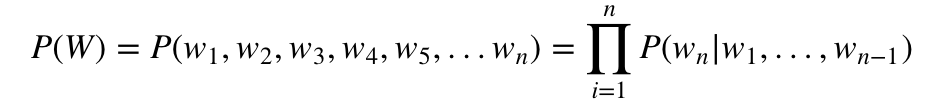

## 통계적 언어모델 (Statistical Language Model, SLM)

### 조건부 확률

두 확률 P(A), P(B)에 대해서 아래 공식이 성립

- p(B|A) = P(A,B) / P(A)
- P(A,B) = P(A) * P(B|A)

4개의 확률이 조건부 확률의 관계일 때

- P(A,B,C,D) = P(A) *P(B|A)* P(C|A,B) * P(D|A,B,C)

조건부 확률의 연쇄법칙

- P(x1,x2,x3...xn) = P(x1) *P(x2|x1)* P(x3|x1,x2)...P(xn|x1...xn−1)

### 문장에 대한 확률

문장 'An adorable little boy is spreading smiles'의 확률 P(An adorable little boy is spreading smiles) =

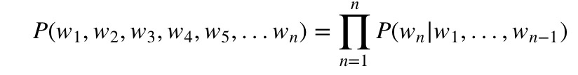

즉,

P(An adorable little boy is spreading smiles)= P(An)×P(adorable|An)×P(little|An adorable)×P(boy|An adorable little)×P(is|An adorable little boy) ×P(spreading|An adorable little boy is)×P(smiles|An adorable little boy is spreading)

- 각 단어는 문맥관계로 앞서 나온 단어의 영향을 받아 나타나게 되므로, 문장의 확률을 구할 때는 조건부 확률을 사용해야 하며, 한 문장이 나타날 확률은 각 단어에 대한 예측확률들의 곱이다.

### 카운트 기반의 접근

SLM은 이전 단어로부터 카운트에 기반하여 다음 단어에 대한 확률을 계산한다.

An adorable little boy가 나왔을 때 다음 단어로 is가 나타날 확률 = P(is|An adorable little boy)

- P(is|An adorable little boy) = count(An adorable little boy is) / count(An adorable little boy )

### 카운트 기반 접근의 한계 - 희소 문제(Sparsity Problem)

- 언어모델은 실생활에서 사용되는 언어의 확률 분포를 근사모델링 한다. 정확하게 알아낼 방법은 없지만, 현실에서도 An adorable little boy가 나왔을 때 다음 단어로 is가 나타날 확률이 존재하긴 함. 이것을 현실에서의 확률분포라고 명칭했을 때, 많은 코퍼스로 훈련을 진행한 뒤 언어모델을 통해 현실에서의 확률 분포를 근사하는 것이 언어모델의 목표이다.
- 카운트를 기반으로 접근하기 위해서는 굉장히 방대한 양의 언어데이터가 필요할 것임.
- 만약 기계가 훈련한 코퍼스에 An adorable little boy라는 단어시퀀스는 여러번 등장하였으나 그 뒤에 is가 붙은 단어시퀀스가 존재하지 않는다면, 이 경우 확률은 0이 된다.
- 따라서 충분한 데이터를 관측하지 못하여, 언어를 제대로 모델링하지 못하는 문제를 희소문제(sparsity problem)이라고 한다.

N-gram이나 backoff와 같은 여러 일반화(generalization) 기법들은 희소문제에 대한 근본적인 해결책이 되지 못하고 있다. 이것이 인공신경망 언어모델(8챕터)로 넘어가게 되는 이유가 됨.

## N-gram 언어모델

- 조건부 확률로 이전에 등장한 모든 단어를 고려하는 것이 아니라, 일부 단어만 고려하는 접근방법 사용.
- 몇 개의 단어를 볼거냐를 결정하는게 n-gram에서의 n값이다.

### 코퍼스에서 카운트하지 못하는 경우의 감소.

- SLM의 한계는 확률을 계산하고 싶은 문장 혹은 단어가 없을 수 있다는 것임.
- ex) An adorable little boy + is
- ex) boy + is
- 단어 시퀀스의 길이가 짧으면 확률을 계산할 수 있는 가능성이 높아짐.
- P(is|An adorable little boy) ≈ P(is|boy)
- P(is|An adorable little boy) ≈ P(is|little boy)

### N-gram

- N-gram은 연속적인 단어 나열을 의미함.
- 코퍼스에서 애초에 n개의 단어 뭉치 단위로 끊고, 이것을 하나의 토큰으로 간주함.

  ```
    unigrams : an, adorable, little, boy, is, spreading, smiles

    bigrams : an adorable, adorable little, little boy, boy is, is spreading, spreading  smiles

    trigrams : an adorable little, adorable little boy, little boy is, boy is spreading, is spreading smiles

    4-grams : an adorable little boy, adorable little boy is, little boy is spreading, boy is spreading smiles
  ```

- 4-gram을 이용한 언어모델에서 An adorable little boy is spreading 다음에 나올 단어를 예측하고 싶을 때, 등장할 단어로부터 n-1개의 단어, 즉 앞에 3개의 단어인 'boy is spreading'만을 고려한다.

### N-gram Lunguage Model의 한계

- 위의 예제와 같이 boy is spreading 만을 고려하게 된다면 그 앞의 단어시퀀스인 an adorable little은 반영되지 않는다.
- 이러한 것처럼, 의도하고 싶은 대로 문장을 만들어내지 못할 가능성이 생기기에, 전체를 고려한 언어모델보다는 정확도가 떨어짐.
- 여전히 희소문제 발생 가능성이 있음.
- n을 얼마나 선택해야 할 지에 대한 문제가 발생

# 카운트 기반의 단어표현

## Bag of Words (BoW)

### Bag of Words란?

- 단어들의 순서는 전혀 고려하지 않고, 출현빈도(frequency)에만 집중하는 텍스트 데이터의 수치화 표현 방법.
- 직역하면 '단어들의 가방'이란 뜻.
- 생성방법
  1. 각 단어에 고유한 정수 인덱스를 부여함. (정수인코딩)
  2. 각 인덱스의 위치에 단어 토큰의 등장 횟수를 기록한 벡터를 만듦.

```python
from konlpy.tag import Okt
import re
okt=Okt()

token=re.sub("(\.)","","정부가 발표하는 물가상승률과 소비자가 느끼는 물가상승률은 다르다.")
# 정규 표현식을 통해 온점을 제거하는 정제 작업입니다.
token=okt.morphs(token)
# OKT 형태소 분석기를 통해 토큰화 작업을 수행한 뒤에, token에다가 넣습니다.

word2index={}
bow=[]
for voca in token:
         if voca not in word2index.keys():
             word2index[voca]=len(word2index)
# token을 읽으면서, word2index에 없는 (not in) 단어는 새로 추가하고, 이미 있는 단어는 넘깁니다.
             bow.insert(len(word2index)-1,1)
# BoW 전체에 전부 기본값 1을 넣어줍니다. 단어의 개수는 최소 1개 이상이기 때문입니다.
         else:
            index=word2index.get(voca)
# 재등장하는 단어의 인덱스를 받아옵니다.
            bow[index]=bow[index]+1
# 재등장한 단어는 해당하는 인덱스의 위치에 1을 더해줍니다. (단어의 개수를 세는 것입니다.)
print(word2index)
bow
```

```
{'정부': 0, '가': 1, '발표': 2, '하는': 3, '물가상승률': 4, '과': 5, '소비자': 6, '느끼는': 7, '은': 8, '다르다': 9}
```

```
[1, 2, 1, 1, 2, 1, 1, 1, 1, 1]
```

### Bag of Words의 다른 예제들

```python
from konlpy.tag import Okt
import re
okt=Okt()

token=re.sub("(\.)","","소비자는 주로 소비하는 상품을 기준으로 물가상승률을 느낀다.")
# 정규 표현식을 통해 온점을 제거하는 정제 작업입니다.
token=okt.morphs(token)
# OKT 형태소 분석기를 통해 토큰화 작업을 수행한 뒤에, token에다가 넣습니다.

word2index={}
bow=[]
for voca in token:
         if voca not in word2index.keys():
             word2index[voca]=len(word2index)
# token을 읽으면서, word2index에 없는 (not in) 단어는 새로 추가하고, 이미 있는 단어는 넘깁니다.
             bow.insert(len(word2index)-1,1)
# BoW 전체에 전부 기본값 1을 넣어줍니다. 단어의 개수는 최소 1개 이상이기 때문입니다.
         else:
            index=word2index.get(voca)
# 재등장하는 단어의 인덱스를 받아옵니다.
            bow[index]=bow[index]+1
# 재등장한 단어는 해당하는 인덱스의 위치에 1을 더해줍니다. (단어의 개수를 세는 것입니다.)
print(word2index)
bow
```

```
{'소비자': 0, '는': 1, '주로': 2, '소비': 3, '하는': 4, '상품': 5, '을': 6, '기준': 7, '으로': 8, '물가상승률': 9, '느낀다': 10}
```

```
[1, 1, 1, 1, 1, 1, 2, 1, 1, 1, 1]
```

```python
from konlpy.tag import Okt
import re
okt=Okt()

token=re.sub("(\.)","","정부가 발표하는 물가상승률과 소비자가 느끼는 물가상승률은 다르다. 소비자는 주로 소비하는 상품을 기준으로 물가상승률을 느낀다.")
# 정규 표현식을 통해 온점을 제거하는 정제 작업입니다.
token=okt.morphs(token)
# OKT 형태소 분석기를 통해 토큰화 작업을 수행한 뒤에, token에다가 넣습니다.

word2index={}
bow=[]
for voca in token:
         if voca not in word2index.keys():
             word2index[voca]=len(word2index)
# token을 읽으면서, word2index에 없는 (not in) 단어는 새로 추가하고, 이미 있는 단어는 넘깁니다.
             bow.insert(len(word2index)-1,1)
# BoW 전체에 전부 기본값 1을 넣어줍니다. 단어의 개수는 최소 1개 이상이기 때문입니다.
         else:
            index=word2index.get(voca)
# 재등장하는 단어의 인덱스를 받아옵니다.
            bow[index]=bow[index]+1
# 재등장한 단어는 해당하는 인덱스의 위치에 1을 더해줍니다. (단어의 개수를 세는 것입니다.)
print(word2index)
bow
```

```
{'정부': 0, '가': 1, '발표': 2, '하는': 3, '물가상승률': 4, '과': 5, '소비자': 6, '느끼는': 7, '은': 8, '다르다': 9, '는': 10, '주로': 11, '소비': 12, '상품': 13, '을': 14, '기준': 15, '으로': 16, '느낀다': 17}
```

```
[1, 2, 1, 2, 3, 1, 2, 1, 1, 1, 1, 1, 1, 1, 2, 1, 1, 1]
```

### CountVectorizer 클래스로 BoW 만들기

- sklearn

```python
from sklearn.feature_extraction.text import CountVectorizer
corpus = ['you know I want your love. because I love you.']
vector = CountVectorizer()
print(vector.fit_transform(corpus).toarray()) # 코퍼스로부터 각 단어의 빈도 수를 기록한다.
print(vector.vocabulary_) # 각 단어의 인덱스가 어떻게 부여되었는지를 보여준다.
```

```
[[1 1 2 1 2 1]]
{'you': 4, 'know': 1, 'want': 3, 'your': 5, 'love': 2, 'because': 0}
```

### 불용어를 제거한 BoW 만들기

1. 사용자가 직접 정의한 불용어 사용

```python
from sklearn.feature_extraction.text import CountVectorizer

text=["Family is not an important thing. It's everything."]
vect = CountVectorizer(stop_words=["the", "a", "an", "is", "not"])
print(vect.fit_transform(text).toarray())
print(vect.vocabulary_)
```

```
[[1 1 1 1 1]]
{'family': 1, 'important': 2, 'thing': 4, 'it': 3, 'everything': 0}
```

1. CountVectorizer에서 제공하는 자체 불용어 사용

```python
from sklearn.feature_extraction.text import CountVectorizer

text=["Family is not an important thing. It's everything."]
vect = CountVectorizer(stop_words="english")
print(vect.fit_transform(text).toarray())
print(vect.vocabulary_)
```

```
[[1 1 1]]
{'family': 0, 'important': 1, 'thing': 2}
```

1. NLTK에서 지원하는 불용어 사용

```python
import nltk
nltk.download('stopwords')
from sklearn.feature_extraction.text import CountVectorizer
from nltk.corpus import stopwords

text=["Family is not an important thing. It's everything."]
sw = stopwords.words("english")
vect = CountVectorizer(stop_words =sw)
print(vect.fit_transform(text).toarray())
print(vect.vocabulary_)
```

```
[[1 1 1 1]]
{'family': 1, 'important': 2, 'thing': 3, 'everything': 0}
```

## 문서 단어 행렬 (Document-Term Matrix, DTM)

- 서로 다른 BoW들을 결합한 표현 방법임.
- 행과 열을 반대로 선택하면 TDM이라고도 부름.
- 서로 다른 문서들을 비교할 수 있음.

### 문서 단어 행렬(DTM)의 표기법

- DTM은 다수의 문서에서 등장하는 각 단어들의 빈도를 행렬로 표현한 것임.

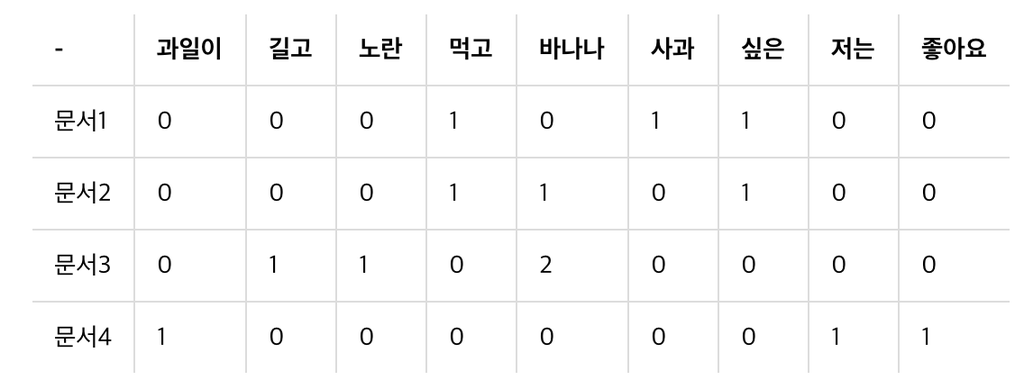

### 문서 단어 행렬의 한계

1. 희소표현 (Sparse representation)
   - 각 행을 문서벡터라고 생각하면, 원-핫 벡터와 마찬가지로 전체 단어 집합의 크기를 가짐.
   - 코퍼스의 크기가 큰 경우 수백만의 차원을 가질 수도 있음. 이 경우, 문서 벡터 대부분의 값이 0일 수도 있다.
   - 따라서 BoW 표현을 사용할 때 단어집합의 크기를 줄이는 일이 매우 중요함. 토크나이징을 통한 정규화로 크기를 줄일 수 있음.
2. 단순 빈도 수 기반 접근
   - 세 개의 문서에서 the가 가장 빈도수가 높았다고 해서, 세 문서가 유사하다고 판단할 수는 없음.
   - 불용어와 중요한 단어에 대한 가중치를 줄 수 있는 방법: TF-IDF

## TF-IDF(Term Frequency-Inverse Document Freq)

### TF-IDF(단어 빈도 - 역 문서 빈도)

- TF-IDF는 단어빈도와 역문서빈도마다 중요한 정도를 가중치로 주는 방법이다. DTM을 만든 이후 TF-IDF 가중치를 부여한다.
- 문서 유사도를 구하는 작업이나 검색시스템에서 사용될 수 있음.
- TF-IDF는 TF와 IDF를 곱한 값이다.
  1. tf(d, t): 특정 문서 d에서 특정 단어 t의 등장횟수
  2. df(t): 특정 단어 t가 등장한 문서의 수
  3. idf(d, t): df(t)의 반비례 수
     - 단순 역수가 아니라 log를 취하고 분모에 1을 더해줌. 로그를 사용하지 않은 단순 역수이면 문서의 수가 많아질수록 idf값이 커지게 된다.

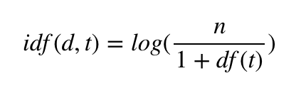

     - n: 문서의 개수

### 파이썬으로 TF-IDF 직접 구현하기

```python
import pandas as pd # 데이터프레임 사용을 위해
from math import log # IDF 계산을 위해
docs = [
  '먹고 싶은 사과',
  '먹고 싶은 바나나',
  '길고 노란 바나나 바나나',
  '저는 과일이 좋아요'
]
vocab = list(set(w for doc in docs for w in doc.split()))
vocab.sort()

N = len(docs) # 총 문서의 수

def tf(t, d):
    return d.count(t)

def idf(t):
    df = 0
    for doc in docs:
        df += t in doc
    return log(N/(df + 1))

def tfidf(t, d):
    return tf(t,d)* idf(t)

result = []
for i in range(N): # 각 문서에 대해서 아래 명령을 수행
    result.append([])
    d = docs[i]
    for j in range(len(vocab)):
        t = vocab[j]
        result[-1].append(tf(t, d))

tf_ = pd.DataFrame(result, columns = vocab)
tf_
```

|  | 과일이 | 길고 | 노란 | 먹고 | 바나나 | 사과 | 싶은 | 저는 | 좋아요 |
| --- | --- | --- | --- | --- | --- | --- | --- | --- | --- |
| 0 | 0 | 0 | 0 | 1 | 0 | 1 | 1 | 0 | 0 |
| 1 | 0 | 0 | 0 | 1 | 1 | 0 | 1 | 0 | 0 |
| 2 | 0 | 1 | 1 | 0 | 2 | 0 | 0 | 0 | 0 |
| 3 | 1 | 0 | 0 | 0 | 0 | 0 | 0 | 1 | 1 |

```python
result = []
for j in range(len(vocab)):
    t = vocab[j]
    result.append(idf(t))

idf_ = pd.DataFrame(result, index = vocab, columns = ["IDF"])
idf_
```

|  | IDF |
| --- | --- |
| 과일이 | 0.693147 |
| 길고 | 0.693147 |
| 노란 | 0.693147 |
| 먹고 | 0.287682 |
| 바나나 | 0.287682 |
| 사과 | 0.693147 |
| 싶은 | 0.287682 |
| 저는 | 0.693147 |
| 좋아요 | 0.693147 |

```python
result = []
for i in range(N):
    result.append([])
    d = docs[i]
    for j in range(len(vocab)):
        t = vocab[j]

        result[-1].append(tfidf(t,d))

tfidf_ = pd.DataFrame(result, columns = vocab)
tfidf_
```

|  | 과일이 | 길고 | 노란 | 먹고 | 바나나 | 사과 | 싶은 | 저는 | 좋아요 |
| --- | --- | --- | --- | --- | --- | --- | --- | --- | --- |
| 0 | 0.000000 | 0.000000 | 0.000000 | 0.287682 | 0.000000 | 0.693147 | 0.287682 | 0.000000 | 0.000000 |
| 1 | 0.000000 | 0.000000 | 0.000000 | 0.287682 | 0.287682 | 0.000000 | 0.287682 | 0.000000 | 0.000000 |
| 2 | 0.000000 | 0.693147 | 0.693147 | 0.000000 | 0.575364 | 0.000000 | 0.000000 | 0.000000 | 0.000000 |
| 3 | 0.693147 | 0.000000 | 0.000000 | 0.000000 | 0.000000 | 0.000000 | 0.000000 | 0.693147 | 0.693147 |

### 싸이킷런을 이용한 DTM과 TF-IDE

```python
from sklearn.feature_extraction.text import CountVectorizer
corpus = [
    'you know I want your love',
    'I like you',
    'what should I do ',
]
vector = CountVectorizer()
print(vector.fit_transform(corpus).toarray()) # 코퍼스로부터 각 단어의 빈도 수를 기록한다.
print(vector.vocabulary_) # 각 단어의 인덱스가 어떻게 부여되었는지를 보여준다.
```

```
[[0 1 0 1 0 1 0 1 1]
 [0 0 1 0 0 0 0 1 0]
 [1 0 0 0 1 0 1 0 0]]
{'you': 7, 'know': 1, 'want': 5, 'your': 8, 'love': 3, 'like': 2, 'what': 6, 'should': 4, 'do': 0}
```

```python
from sklearn.feature_extraction.text import TfidfVectorizer
corpus = [
    'you know I want your love',
    'I like you',
    'what should I do ',
]
tfidfv = TfidfVectorizer().fit(corpus)
print(tfidfv.transform(corpus).toarray())
print(tfidfv.vocabulary_)
```

```
[[0.         0.46735098 0.         0.46735098 0.         0.46735098
  0.         0.35543247 0.46735098]
 [0.         0.         0.79596054 0.         0.         0.
  0.         0.60534851 0.        ]
 [0.57735027 0.         0.         0.         0.57735027 0.
  0.57735027 0.         0.        ]]
{'you': 7, 'know': 1, 'want': 5, 'your': 8, 'love': 3, 'like': 2, 'what': 6, 'should': 4, 'do': 0}
```

# 문서유사도 (Document Similarity)

## 코사인 유사도 (Cosine Similarity)

### 코사인 유사도란?

- 두 벡터 간의 코사인 각도를 이용하여 구할 수 있는 두 벡터의 유사도를 의미한다.
- 두 벡터 방향이 완전히 동일한 경우 1, 90도의 각을 이루면 0, 180도로 반대방향이면 -1의 값을 가진다. 1에 가까울수록 유사도가 높음. 즉, 두 벡터가 가리키는 방향이 얼마나 유사한가를 의미한다.

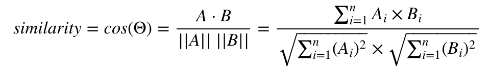

- 문서 단어 행렬이나 TF-IDF행렬을 통해 문서 유사도를 구하는 경우, 각각 행렬이 각각의 특징 벡터 A, B가 된다.

```python
from numpy import dot
from numpy.linalg import norm
import numpy as np
def cos_sim(A, B):
       return dot(A, B)/(norm(A)*norm(B))
doc1=np.array([0,1,1,1])
doc2=np.array([1,0,1,1])
doc3=np.array([2,0,2,2])
print(cos_sim(doc1, doc2)) #문서1과 문서2의 코사인 유사도
print(cos_sim(doc1, doc3)) #문서1과 문서3의 코사인 유사도
print(cos_sim(doc2, doc3)) #문서2과 문서3의 코사인 유사도
```

```
0.6666666666666667
0.6666666666666667
1.0000000000000002
```

### 유사도를 이용한 추천 시스템 구현

```python
import pandas as pd
data = pd.read_csv('/content/movies_metadata.csv', low_memory=False)
# 예를 들어 윈도우 바탕화면에 해당 파일을 위치시킨 저자의 경우
# pd.read_csv(r'C:\Users\USER\Desktop\movies_metadata.csv', low_memory=False)
data.head(2)
data=data.head(20000)
print(data['overview'].isnull().sum())
data['overview'] = data['overview'].fillna('') # NULL을 ''로 변경
```

```
135
```

```python
from sklearn.feature_extraction.text import TfidfVectorizer
tfidf = TfidfVectorizer(stop_words='english')
tfidf_matrix = tfidf.fit_transform(data['overview'])
# overview에 대해서 tf-idf 수행
print(tfidf_matrix.shape) # 2만개의 영화를 위해 47,487개의 단어가 사용되었음.
```

```
(20000, 47487)
```

```python
# 코사인 유사도 구하기
from sklearn.metrics.pairwise import linear_kernel
cosine_sim = linear_kernel(tfidf_matrix, tfidf_matrix)
cosine_sim
```

```
array([[1.        , 0.01575748, 0.        , ..., 0.        , 0.        ,
        0.        ],
       [0.01575748, 1.        , 0.04907345, ..., 0.        , 0.        ,
        0.        ],
       [0.        , 0.04907345, 1.        , ..., 0.        , 0.        ,
        0.        ],
       ...,
       [0.        , 0.        , 0.        , ..., 1.        , 0.        ,
        0.08375766],
       [0.        , 0.        , 0.        , ..., 0.        , 1.        ,
        0.        ],
       [0.        , 0.        , 0.        , ..., 0.08375766, 0.        ,
        1.        ]])
```

```python
indices = pd.Series(data.index, index=data['title']).drop_duplicates()
print(indices.head())
```

```
title
Toy Story                      0
Jumanji                        1
Grumpier Old Men               2
Waiting to Exhale              3
Father of the Bride Part II    4
dtype: int64
```

```python
idx = indices['Father of the Bride Part II']
print(idx)
```

```
4
```

```python
def get_recommendations(title, cosine_sim=cosine_sim):
    # 선택한 영화의 타이틀로부터 해당되는 인덱스를 받아옵니다. 이제 선택한 영화를 가지고 연산할 수 있습니다.
    idx = indices[title]

    # 모든 영화에 대해서 해당 영화와의 유사도를 구합니다.
    sim_scores = list(enumerate(cosine_sim[idx]))

    # 유사도에 따라 영화들을 정렬합니다.
    sim_scores = sorted(sim_scores, key=lambda x: x[1], reverse=True)

    # 가장 유사한 10개의 영화를 받아옵니다.
    sim_scores = sim_scores[1:11]

    # 가장 유사한 10개의 영화의 인덱스를 받아옵니다.
    movie_indices = [i[0] for i in sim_scores]

    # 가장 유사한 10개의 영화의 제목을 리턴합니다.
    return data['title'].iloc[movie_indices]

get_recommendations('The Dark Knight Rises')
```

```
12481                            The Dark Knight
150                               Batman Forever
1328                              Batman Returns
15511                 Batman: Under the Red Hood
585                                       Batman
9230          Batman Beyond: Return of the Joker
18035                           Batman: Year One
19792    Batman: The Dark Knight Returns, Part 1
3095                Batman: Mask of the Phantasm
10122                              Batman Begins
Name: title, dtype: object
```